# Module Five Activity

For the module five activity, you will write Python code to create clear and informative data visualizations from the provided data set `Most-Recent-Cohorts-Field-of-Study.csv`. Your code should be well-organized and reflect a clear understanding of each step in the visualization process.

*Note:* there are two parts to this assignment. Part One is the data visualization coding activity. Part Two is the reflection paper.

Once your code is complete, you will download this notebook as an HTML file by clicking **File**, then **Download As**, then **HTML (.html)** from the Jupyter menu bar. Validate that your code, output, and all six visualizations (rendered as images using the display() function) are visible in the html file before submission.

*Missing Blocks:* Ensure that you have clicked **Run** for all blocks before downloading as an HTML file or the block may be missing from your submission. **Images** must be called using the *display()* function, for example: **display(Image(filename="output/{image_name}.png"))**

Specifically, you must address the items from the rubric criteria.

### Part One: Data Visualization

#### Prepare the given data set for visualization. Consider the following:

- Are there any columns you can remove?
- Are filters or groupings needed?
- Are the data values structured for your chart types?

#### Clean the given data set for visualization using Python. Consider the following:

- Are there any missing or invalid values?
- Are there any unclear column names?
- Are the data types correct for each column (e.g., numeric, categorical, datetime)?

#### Create multiple types of visualizations using Python. Include the following:

- Dendrogram
- PCA scatterplot
- Cluster size distribution
- Feature importance heatmap
- Trend chart
- Scatterplot

*Note:* You will need to ensure that you have created at least one of each of the visual types listed above.

### Part 2: Reflection

*This part is to be completed in a word document, using the output here to answer the topics.*

#### Identify patterns in the data. Consider the following:

- Are there any clear trends, clusters, or outliers visible in your visualizations?
- Are certain variables showing consistent behavior or relationships?
- Are the patterns similar across different visualization types?

#### Draw conclusions from the patterns. Consider the following:

- Are your conclusions clearly based on the patterns you observed?
- Are your findings supported by multiple visuals or data points?

#### Explain how the visualizations validate your findings. Consider the following:

- Are specific chart elements (e.g., color, scale, labels) helping to highlight your findings?
- Are the insights you found something you could not easily see without the visuals?

#### Write a summary of the visualization choices you made. Include the following:

- An explanation of the types of charts you used
- An explanation of the formatting decisions to support visual clarity

*To Begin:* This Python template program has been broken down into segments as a guide for what steps you should do at a minimum to complete this activity. Look for the **# To Do:** comments. These are placeholders for you to provide Python code segments. Fill out all **# To Do:** code segments to complete this program.  
*Once Complete:* Execute a "Kernel restart and run all" to verify that all your code works as a single unit by clicking **Kernel**, then **Restart & Run All** before downloading as html.

*Hint:* If you need to install additional packages, see one of the earlier modules on how to configure and call a requirements.txt file.

## Import the Required Packages

- **pandas (pd):** For reading and manipulating the dataset.
- **MinMaxScaler:** A preprocessing tool from sklearn to normalize data values between 0 and 1.
- **PCA:** Principal Component Analysis (dimensionality reduction) from sklearn for visualizing clusters in 2D.
- **dendrogram, linkage, fcluster:** Tools from scipy for performing hierarchical clustering and visualizing its results.
- **matplotlib.pyplot (plt):** For creating charts and saving visuals.
- **seaborn (sns):** For advanced and visually appealing charts.
- **numpy (np):** For numerical operations like arrays and aggregations.

```python
import pandas as pd   # for reading & manipulating the dataset
from sklearn.preprocessing import MinMaxScaler    # a preprocessing tool from sklearn to normalize data values
                                                                                    # between 0 and 1
from sklearn.decomposition import PCA  # Principal Component Analysis (dimensionality reduction) from
                                                                   # sklearn for visualizing clusters in 2D
from scipy.cluster.hierarchy import dendrogram, linkage, fcluster    # tools from scipy for performing hierarchical clustering & visualizing its results
import matplotlib.pyplot as plt     #  for creating charts & saving visuals
import seaborn as sns    #  for advanced & visually appealing charts
import numpy as np      # for numerical operations like arrays & aggregations

from IPython.display import Image, display # for image rendering in html output
```

# Part One: Data Visualization

## Loading the Data

*Hints:* Use **pd.read_csv** to read a CSV file and load it into a DataFrame (data). Use **try block** to ensures the program handles errors gracefully if the file cannot be loaded (e.g., missing or incorrect path). Use **exit()** to stop the program if an error occurs.

```python
print("Loading dataset...")
# To Do: Use the given dataset named "Most-Recent-Cohorts-Field-of-Study.csv" for this assignment
# Load this dataset
# For secure coding, put this action in a try/catch block

#Search for the dataset that is located in the data folder. If it cannot be found, then display an error.
try:

    data = pd.read_csv("data/Most-Recent-Cohorts-Field-of-Study.csv")

    print("Dataset has been loaded successfully.")
except FileNotFoundError:

    print("Error: the dataset has not been found. Please check that your filename and or path are correct.")

    sys.exit()
except Exception as e:

    print(f"An unexpected error occurred while loading the dataset: {e}")
    sys.exit()

#Displays the data to make sure that the data has been properly loaded.
data.head()
```

```
Loading dataset...
Dataset has been loaded successfully.
```

|  | UNITID | OPEID6 | INSTNM | CONTROL | MAIN | CIPCODE | CIPDESC | CREDLEV | CREDDESC | IPEDSCOUNT1 | ... | EARN_COUNT_PELL_WNE_5YR | EARN_PELL_WNE_MDN_5YR | EARN_COUNT_NOPELL_WNE_5YR | EARN_NOPELL_WNE_MDN_5YR | EARN_COUNT_MALE_WNE_5YR | EARN_MALE_WNE_MDN_5YR | EARN_COUNT_NOMALE_WNE_5YR | EARN_NOMALE_WNE_MDN_5YR | EARN_COUNT_HIGH_CRED_5YR | EARN_IN_STATE_5YR |
| --- | --- | --- | --- | --- | --- | --- | --- | --- | --- | --- | --- | --- | --- | --- | --- | --- | --- | --- | --- | --- | --- |
| 0 | 100654.0 | 1002 | Alabama A & M University | Public | 1 | 100 | Agriculture, General. | 3 | Bachelor's Degree | NaN | ... | PS | PS | PS | PS | PS | PS | PS | PS | PS | PS |
| 1 | 100654.0 | 1002 | Alabama A & M University | Public | 1 | 101 | Agricultural Business and Management. | 3 | Bachelor's Degree | NaN | ... | PS | PS | PS | PS | PS | PS | PS | PS | PS | PS |
| 2 | 100654.0 | 1002 | Alabama A & M University | Public | 1 | 109 | Animal Sciences. | 3 | Bachelor's Degree | 3.0 | ... | PS | PS | PS | PS | PS | PS | PS | PS | PS | PS |
| 3 | 100654.0 | 1002 | Alabama A & M University | Public | 1 | 110 | Food Science and Technology. | 3 | Bachelor's Degree | 7.0 | ... | PS | PS | PS | PS | PS | PS | PS | PS | PS | PS |
| 4 | 100654.0 | 1002 | Alabama A & M University | Public | 1 | 110 | Food Science and Technology. | 5 | Master's Degree | 4.0 | ... | PS | PS | PS | PS | PS | PS | PS | PS | PS | PS |

5 rows × 174 columns

## Display Dataset Information

*Hints:* Use **data.columns.tolist()** to extract and print all column names. Use **data.index.tolist()** to show the index values of the dataset (e.g., row numbers). Use **data.head()** to display the top 5 rows to give an overview of the data.

```python
print("Column Names:")
# To Do: Print all column names

#Lists all of the column names.
print(data.columns.tolist())
```

```
Column Names:
['UNITID', 'OPEID6', 'INSTNM', 'CONTROL', 'MAIN', 'CIPCODE', 'CIPDESC', 'CREDLEV', 'CREDDESC', 'IPEDSCOUNT1', 'IPEDSCOUNT2', 'DEBT_ALL_STGP_ANY_N', 'DEBT_ALL_STGP_ANY_MEAN', 'DEBT_ALL_STGP_ANY_MDN', 'DEBT_ALL_STGP_EVAL_N', 'DEBT_ALL_STGP_EVAL_MEAN', 'DEBT_ALL_STGP_EVAL_MDN', 'DEBT_ALL_PP_ANY_N', 'DE…
```

```python
print("Row Index Labels:")
# To Do: Print all row data Labels

#Lists all of the row index values
print(data.index.tolist())
```

```
Row Index Labels:
[0, 1, 2, 3, 4, 5, 6, 7, 8, 9, 10, 11, 12, 13, 14, 15, 16, 17, 18, 19, 20, 21, 22, 23, 24, 25, 26, 27, 28, 29, 30, 31, 32, 33, 34, 35, 36, 37, 38, 39, 40, 41, 42, 43, 44, 45, 46, 47, 48, 49, 50, 51, 52, 53, 54, 55, 56, 57, 58, 59, 60, 61, 62, 63, 64, 65, 66, 67, 68, 69, 70, 71, 72, 73, 74, 75, 76, 7…
```

```python
print("First 5 Rows of the Dataset:")
# To Do: Print the first 5 rows of the dataset

#Shows a preview of the first 5 rows of the dataset.
print(data.head())
```

```
First 5 Rows of the Dataset:
     UNITID  OPEID6                    INSTNM CONTROL  MAIN  CIPCODE
0  100654.0    1002  Alabama A & M University  Public     1      100  \
1  100654.0    1002  Alabama A & M University  Public     1      101
2  100654.0    1002  Alabama A & M University  Public     1      109
3  100654.0    1002  Alabama A & M University  Public     1      110
4  100654.0    1002  Alabama A & M University  Public     1      110

                                 CIPDESC  CREDLEV           CREDDESC
0                  Agriculture, General.        3  Bachelor's Degree  \
1  Agricultural Business and Management.        3  Bachelor's Degree
2                       Animal Sciences.        3  Bachelor's Degree
3           Food Science and Technology.        3  Bachelor's Degree
4           Food Science and Technology.        5    Master's Degree

```

[output cut: 29 more lines]

## Inspect and Select Numeric Columns

*Hints:* Use **select_dtypes()** to filter columns with numeric data types (float64 and int64). Removes columns like **UNITID** and **OPEID6**, which are not useful for clustering. Use **dropna()** to remove rows with missing values to clean data for clustering, see also module three sample for additional cleaning examples. Use error handling **try blocks** to ensures the program stops if the column selection fails.

```python
print("Inspecting dataset to select numeric columns for clustering...")
# To Do: In a try/catch block, exclude identifiers 'UNITID' and 'OPEID6',
#        then print the numeric columns selected for clustering and also print the data for clustering in rows & columns

try:

    #Selects only the numeric columnns that fit in with int64 and float64.
    numeric_data = data.select_dtypes(include = ['int64', 'float64'])

    #Removes the identifier columns if they exist.
    cols_to_drop = ['UNITID', 'OPEID6']
    numeric_data = numeric_data.drop(columns = cols_to_drop, errors = 'ignore')

    #Drops rows that have missing values.
    numeric_data = numeric_data.dropna()

    print("Numeric Columns Selected for Clustering: ")
    print(numeric_data.columns.tolist())

    print("\nShape of the Cleaned Numeric Dataset (rows, columns): ")
    print(numeric_data.shape)

except Exception as e:

    print(f"An error has occurred while selecting numeric columns: {e}")

print("\nPreview of the Cleaned Numeric Data: ")
numeric_data.head()
```

```
Inspecting dataset to select numeric columns for clustering...
Numeric Columns Selected for Clustering:
['MAIN', 'CIPCODE', 'CREDLEV', 'IPEDSCOUNT1', 'IPEDSCOUNT2', 'DISTANCE']

Shape of the Cleaned Numeric Dataset (rows, columns):
(184861, 6)

Preview of the Cleaned Numeric Data:
```

|  | MAIN | CIPCODE | CREDLEV | IPEDSCOUNT1 | IPEDSCOUNT2 | DISTANCE |
| --- | --- | --- | --- | --- | --- | --- |
| 2 | 1 | 109 | 3 | 3.0 | 9.0 | 1 |
| 3 | 1 | 110 | 3 | 7.0 | 10.0 | 1 |
| 4 | 1 | 110 | 5 | 4.0 | 6.0 | 1 |
| 5 | 1 | 110 | 6 | 2.0 | 4.0 | 1 |
| 7 | 1 | 199 | 3 | 6.0 | 6.0 | 1 |

## Normalize the Data

*Hints:* Use **MinMaxScaler()** to scale data values between 0 and 1, ensuring all features are on the same scale. Use **fit_transform()** to fit the scaler to the data and transform it.

```python
print("Normalizing the data using MinMaxScaler...")
# To Do: in a try/catch block, normalize the data using MinMaxScaler

try:

    scaler = MinMaxScaler()

    #Fits the scaler to the numeric data and transforms it.
    normalized_data = scaler.fit_transform(numeric_data)

    #Converts back to a DataFrame for easier viewing and column labels.
    normalized_df = pd.DataFrame(normalized_data, columns = numeric_data.columns)

except Exception as e:
    print(f"An error has occurred while normalizing the data: {e}")


print("Normalization has been completed. Preview of the normalized data: ")
normalized_df.head()
```

```
Normalizing the data using MinMaxScaler...
Normalization has been completed. Preview of the normalized data:
```

|  | MAIN | CIPCODE | CREDLEV | IPEDSCOUNT1 | IPEDSCOUNT2 | DISTANCE |
| --- | --- | --- | --- | --- | --- | --- |
| 0 | 1.0 | 0.001698 | 0.285714 | 0.000330 | 0.000937 | 0.0 |
| 1 | 1.0 | 0.001886 | 0.285714 | 0.000771 | 0.001041 | 0.0 |
| 2 | 1.0 | 0.001886 | 0.571429 | 0.000440 | 0.000625 | 0.0 |
| 3 | 1.0 | 0.001886 | 0.714286 | 0.000220 | 0.000416 | 0.0 |
| 4 | 1.0 | 0.018676 | 0.285714 | 0.000661 | 0.000625 | 0.0 |

## Perform Hierarchical Clustering

*Hints:* Use **linkage()** to compute hierarchical clusters using **Ward's** method, which minimizes variance between clusters. Limit clustering to the first 1000 rows for performance. Use **fcluster()** to assign cluster labels to data points based on the number of clusters (max_clusters).

```python
print("Performing hierarchical clustering using Ward's method...")
# To Do: in a try/catch block use the Ward's method to perform hierarchical clustering, limit max clusters to 4.

try:

    #Limits the list to the first 1000 rows for performance.
    limited_data = normalized_df.iloc[:1000]

    #Computes the hierarchical clustering of the Ward's method.
    Z = linkage(limited_data, method = 'ward')

    #Assigns the cluster labels, 4 clusters max
    max_clusters = 4
    cluster_labels = fcluster(Z, max_clusters, criterion = 'maxclust')

    print("Clustering is complete. First 10 cluster labels: ")
    print(cluster_labels[:10])

except Exception as e:

    print(f"An error has occurred during hierarchical cluster: {e}")
```

```
Performing hierarchical clustering using Ward's method...
Clustering is complete. First 10 cluster labels:
[4 4 3 3 4 3 3 4 4 3]
```

## Generate, Save, and Output Visualizations

Each visualization is created, saved and displayed, with text output provided before and after.

### Dendrogram

*Hints:* A dendrogram displays the hierarchical structure of clusters. Save the image as **dendrogram.png**. Use **display()** to render the image for html file output. Do not use an html image tag in the markdown, or the image will not print in the html download.

```python
print("Creating dendrogram to visualize hierarchical clustering...")
# To Do: Create a dendrogram to visualize hierarchical clustering, and save the dendrogram into a png file under the 'output' folder.

try:

    #Creates the plot
    plt.figure(figsize = (12, 6))
    dendrogram(Z)
    plt.title("Hierarchical Clustering Dendrogram (Ward's Method)")
    plt.xlabel("Data Points")
    plt.ylabel("Distance")

    #Saves to output folder.
    plt.savefig("output/dendrogram.png")
    plt.close()

    print("Dendrogram was successfully saved.")

except Exception as e:

    print(f"An error has occurred while creating the dendrogram: {e}")
```

```
Creating dendrogram to visualize hierarchical clustering...
Dendrogram was successfully saved.
```

```
Dendrogram visualization display...
```

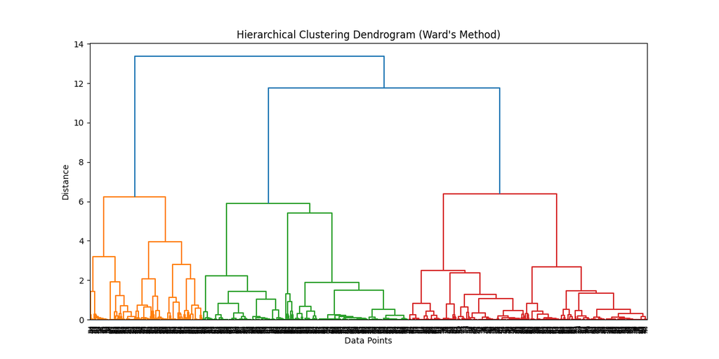

```python
print("Dendrogram visualization display...")
# To Do: output the image using the display() function, for example: display(Image(filename="output/scatter_plot.png"))

#Displays the Dendrogram image.
display(Image(filename = "output/dendrogram.png"))
```

### PCA Scatter Plot

*Hints:* A PCA scatter plot projects high-dimensional data into 2D using PCA for visualization. Save the image as **pca_scatter_plot.png**. Use **display()** to render the image for html file output. Do not use an html image tag in the markdown, or the image will not print in the html download.

```python
print("Creating scatter plot (PCA Reduced) to visualize clusters in 2D...")
# To Do: Create a PCA Scatter Plot to visualize clusters in 2D, and save the PCA Scatter Plot into a png file under the 'output' folder.

try:

    #Reduces to the first 1000 rows to matach the clustering.
    limited_data = normalized_df.iloc[:1000]

    #Performs a PCA to reduce to 2 components.
    pca = PCA(n_components = 2)
    pca_result = pca.fit_transform(limited_data)

    #Extracts PCA components.
    pca_x = pca_result[:, 0]
    pca_y = pca_result[:, 1]

    #Creates a scatter plot.
    plt.figure(figsize = (10, 6))
    plt.scatter(pca_x, pca_y, c = cluster_labels, cmap = 'viridis', s = 20)
    plt.title("PCA Scatter Plot of Hierarchical Clusters")
    plt.xlabel("Principal Component 1")
    plt.ylabel("Principal Component 2")

    #Saves the plot.
    plt.savefig("output/pca_scatter_plot.png")
    plt.close()

    print("PCA scatter plot was successfully saved.")

except Exception as e:

    print(f"An error has occurred while creating the PCA scatter plot: {e}")
```

```
Creating scatter plot (PCA Reduced) to visualize clusters in 2D...
PCA scatter plot was successfully saved.
```

```
PCA scatter plot visualization display...
```

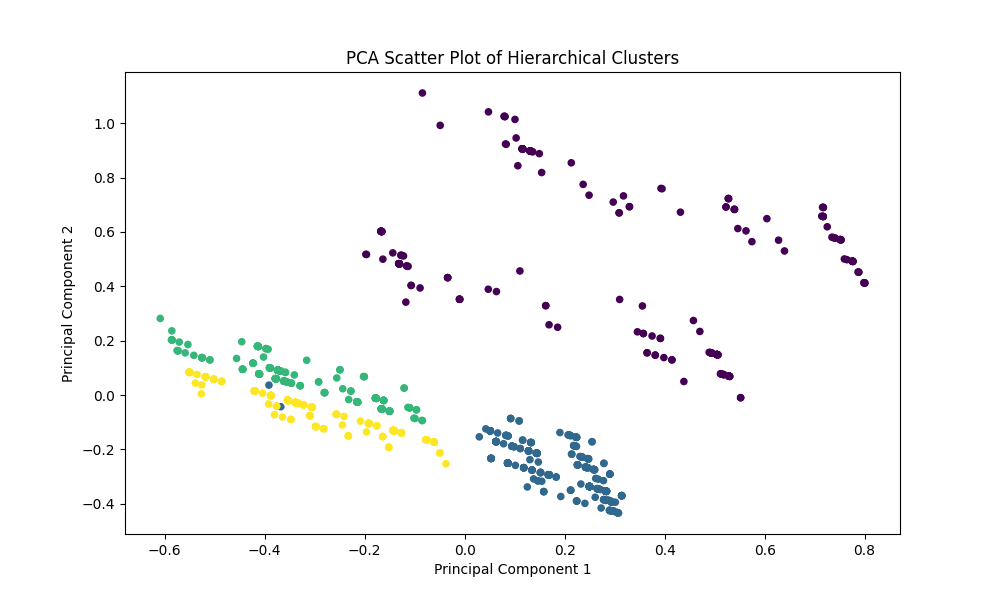

```python
print("PCA scatter plot visualization display...")
# To Do: output the image using the display() function, for example: display(Image(filename="output/pca_scatter_plot.png"))

#Displays the saved image file.
display(Image(filename = "output/pca_scatter_plot.png"))
```

### Cluster Size Distribution

*Hints:* A cluster size distribution displays the population size of each cluster. Save the image as **cluster_size.png**. Use **display()** to render the image for html file output. Do not use an html image tag in the markdown, or the image will not print in the html download.

```python
print("Creating cluster size distribution chart to analyze cluster populations...")
# To Do: Create a cluster size distribution chart, and save it into a png file under the 'output' folder.

try:
    #Counts how many points call into each cluster. The cluster_labels should already be defined from fcluster().
    unique_labels = sorted(set(cluster_labels))
    cluster_counts = [list(cluster_labels).count(label) for label in unique_labels]

    #Creates a bar chart.
    plt.figure(figsize = (8, 5))
    plt.bar(unique_labels, cluster_counts, color = 'purple')
    plt.title("Cluster Size Distribution")
    plt.xlabel("Cluster")
    plt.ylabel("Number of Data Points")

    #Saves the plot.
    plt.savefig("output/cluster_size.png")
    plt.close()

    print("The Cluster Size Distribution chart has been successfully saved.")

except Exception as e:

    print(f"An error has occurred while creating the size distribution chart: {e}")
```

```
Creating cluster size distribution chart to analyze cluster populations...
The Cluster Size Distribution chart has been successfully saved.
```

```
Cluster size distribution visualization display...
```

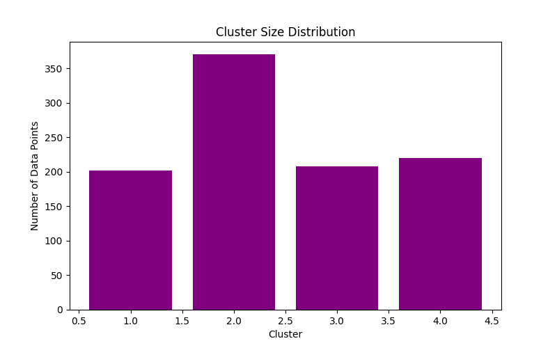

```python
print("Cluster size distribution visualization display...")
# To Do: output the image using the display() function, for example: display(Image(filename="output/cluster_size.png"))

#Displays the saved image.
display(Image(filename = "output/cluster_size.png"))
```

### Feature Importance Heatmap

*Hints:* A feature importance heatmap highlights the average feature values for each cluster. Save the image as **heatmap.png**. Use **display()** to render the image for html file output. Do not use an html image tag in the markdown, or the image will not print in the html download.

```python
print("Creating feature importance heatmap to show mean feature values by cluster...")
# To Do: Create a feature importance heatmap, and save it into a png file under the 'output' folder.

try:

    #Attaches cluster labels to the limited dataset.
    limited_data_with_clusters = limited_data.copy()
    limited_data_with_clusters["Cluster"] = cluster_labels

    #Computes the mean feature values per cluster.
    cluster_means = limited_data_with_clusters.groupby("Cluster").mean()

    #Creates a heatmap.
    plt.figure(figsize = (12, 8))
    sns.heatmap(cluster_means, cmap = 'viridis', annot = False)
    plt.title("Feature Importance Heatmap--Mean Feature Values by Cluster")
    plt.xlabel("Features")
    plt.ylabel("Cluster")

    #Saves the heatmap.
    plt.savefig("output/heatmap.png")
    plt.close()

    print("The Heatmap was successfully saved.")

except Exception as e:

    print(f"An error has occurred while creating the heatmap: {e}")
```

```
Creating feature importance heatmap to show mean feature values by cluster...
The Heatmap was successfully saved.
```

```
Feature important heatmap visualization display...
```

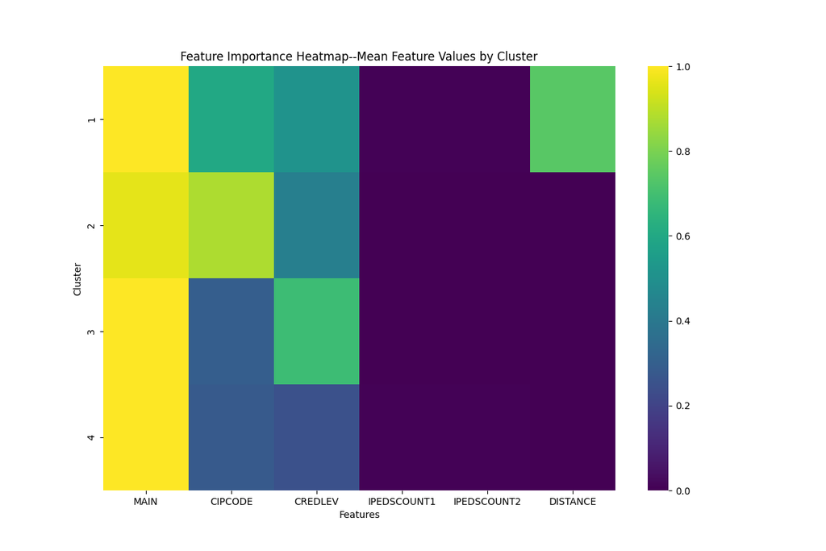

```python
print("Feature important heatmap visualization display...")
# To Do: output the image using the display() function, for example: display(Image(filename="output/heatmap.png"))

#Displays the saved heatmap image.
display(Image(filename = "output/heatmap.png"))
```

### Trend Chart

*Hints:* A trend chart plots trends in a numeric feature across clusters. Save the image as **trend_chart.png**. Use **display()** to render the image for html file output. Do not use an html image tag in the markdown, or the image will not print in the html download.

```python
print("Creating trend chart to analyze a numeric feature across clusters...")
# To Do: Create a trend chart to analyze a numeric feature across clusters, and save it into a png file under the 'output' folder.

try:

    #Attaches the cluster labels to the limited dataset.
    limited_data_with_clusters = limited_data.copy()
    limited_data_with_clusters["Cluster"] = cluster_labels

    #Chooses a numeric feature to analyze. This can be replaced with any column from the numeric_data.columns output.
    feature = numeric_data.columns[0]

    #Computers the mean feature value per cluster.
    trend_values = limited_data_with_clusters.groupby("Cluster")[feature].mean()

    #Creates the trend chart.
    plt.figure(figsize = (8, 5))
    plt.plot(trend_values.index, trend_values.values, marker = 'o', linestyle = '-', color = 'blue')
    plt.title(f"Trend Chart for Feature: {feature}")
    plt.xlabel("Cluster")
    plt.ylabel(f"Mean {feature} Value")

    #Saves the plot.
    plt.savefig("output/trend_chart.png")
    plt.close()

    print("The Trend Chart was successfully saved.")

except Exception as e:

    print(f"An error has occurred while creating the trend chart: {e}")
```

```
Creating trend chart to analyze a numeric feature across clusters...
The Trend Chart was successfully saved.
```

```
Trend chart visualization display...
```

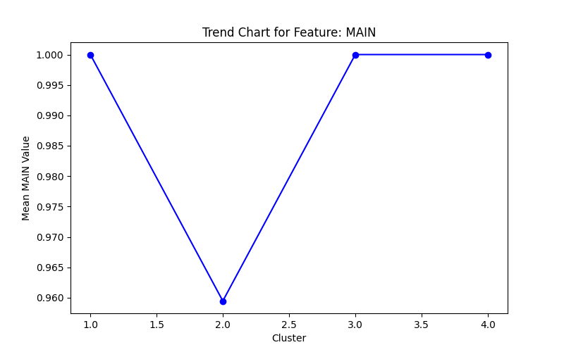

```python
print("Trend chart visualization display...")
# To Do: output the image using the display() function, for example: display(Image(filename="output/trend_chart.png"))

#Displays the saved image.
display(Image(filename = "output/trend_chart.png"))
```

### Scatter Plot

*Hints:* A scatter plot explores the relationship between two features, grouped by clusters. Save the image as **scatter_plot.png**. Use **display()** to render the image for html file output. Do not use an html image tag in the markdown, or the image will not print in the html download.

```python
print("Creating scatter plot of two features...")
# To Do: Create a scatter plot of two features, and save it into a png file under the 'output' folder.

try:

    #Attaches cluster labels to the limited dataset.
    limited_data_with_clusters = limited_data.copy()
    limited_data_with_clusters['Cluster'] = cluster_labels

    #Chooses 2 numeric features that can be changed if desired.
    feature_x = numeric_data.columns[1]
    feature_y = numeric_data.columns[2]

    #Creatures a scatter plot.
    plt.figure(figsize = (10, 6))
    plt.scatter(limited_data_with_clusters[feature_x], limited_data_with_clusters[feature_y],
                c = limited_data_with_clusters["Cluster"], cmap = 'viridis', s = 20)
    plt.title(f"Scatter Plot of {feature_x} vs {feature_y} by Cluster")
    plt.xlabel(feature_x)
    plt.ylabel(feature_y)

    #Saves the plot.
    plt.savefig("output/scatter_plot.png")
    plt.close()

    print("The Scatter Plot was successfully saved.")

except Exception as e:

    print(f"An error has occurred while creating the scatter plot: {e}")
```

```
Creating scatter plot of two features...
The Scatter Plot was successfully saved.
```

```
Scatter plot visualization display...
```

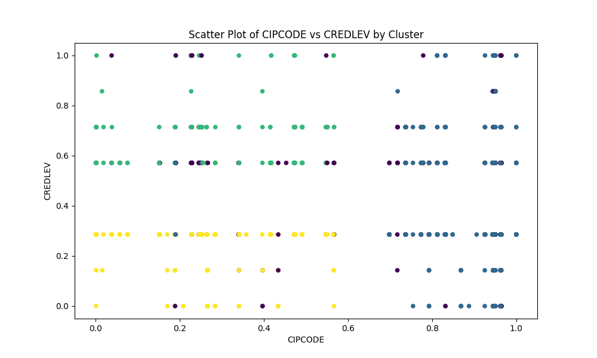

```python
print("Scatter plot visualization display...")
# To Do: output the image using the display() function, for example: display(Image(filename="output/scatter_plot.png"))

#Displays the saved image.
display(Image(filename = "output/scatter_plot.png"))
```

## Part 2: Reflection

*This part is to be completed in a word document, using the output above to answer the topics.*

### Identify patterns in the data. Consider the following:

- Are there any clear trends, clusters, or outliers visible in your visualizations?
- Are certain variables showing consistent behavior or relationships?
- Are the patterns similar across different visualization types?

### Draw conclusions from the patterns. Consider the following:

- Are your conclusions clearly based on the patterns you observed?
- Are your findings supported by multiple visuals or data points?

### Explain how the visualizations validate your findings. Consider the following:

- Are specific chart elements (e.g., color, scale, labels) helping to highlight your findings?
- Are the insights you found something you could not easily see without the visuals?

### Write a summary of the visualization choices you made. Include the following:

- An explanation of the types of charts you used
- An explanation of the formatting decisions to support visual clarity